# Summer of Data Project Progress

Summer of Data Project Progress Juo-Lin Tsai

## Plot Actigraphy Activity

Code creates a list for the actigraphy files in the Actigraphy Data Box folder. The for loop then reads the raw actigraphy data to plot subjects’ actigraphy activity. To loop through the whole folder, change “actigraphy_files[1:2]” to “actigraphy_files”.

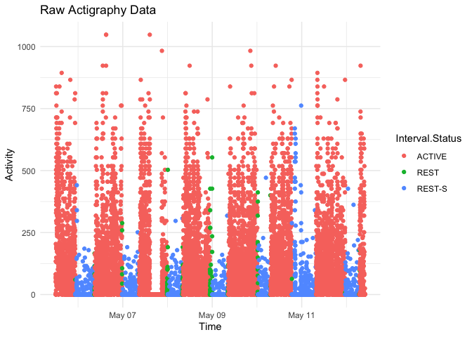

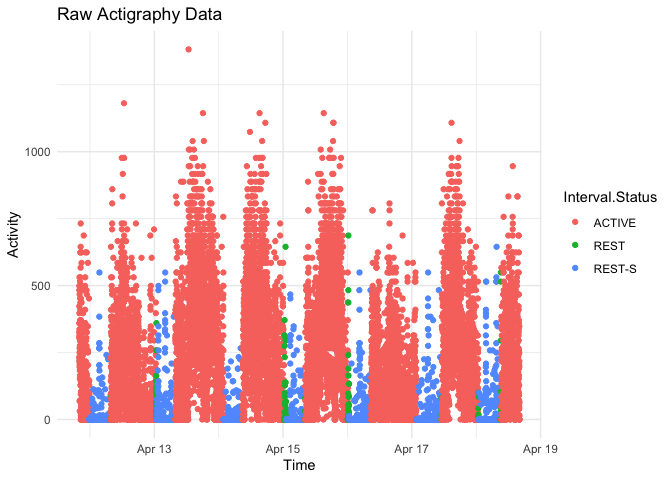

```r
actigraphy_files <- list.files("~/Box/Aging Decision Making R01/RAs/Juo-Lin/data/Actigraphy Data/", full.names = T)

for (file in actigraphy_files[1:2]) {
  d <- read.csv(file, skip = 22)
  p <- d %>%
    mutate(DateTime = as_datetime(paste(d$Date, d$Time))) %>%
    ggplot() +
    geom_point(aes(x = DateTime, y = Activity, color = Interval.Status)) +
    theme_minimal() +
    xlab("Time") +
    ggtitle("Raw Actigraphy Data")
  plot(p)
}
```

By knitting the graphs together in one cohesive document, we took note of subjects with extended periods of 0 (greater than 1/2 day) in their actigraphy activity.

## Check the Extended Periods of 0 Activity

We documented the ID and sleep diary entry of subjects with extended periods of 0 actigraphy activity to look for an alignment in an Excel file.

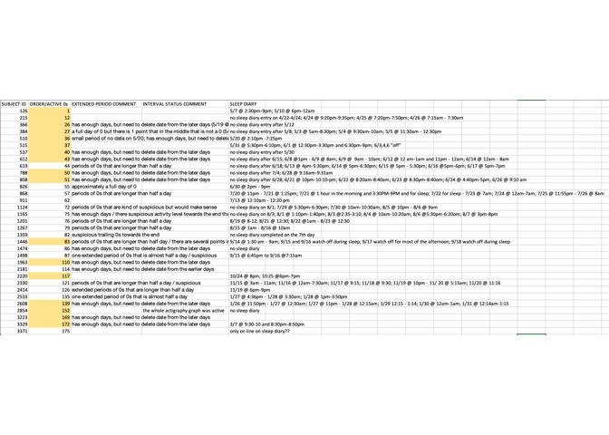

## Pre-process the Actigraphy Files

The Python code pre-processes the actigraphy files by truncating raw actigraphy data into 5 days with 30 second increments and interpolating the missing values. I wrote the function that loops the raw actigraphy files into new csv files.

[figure not shown]

[figure not shown]

[figure not shown]

[figure not shown]

[figure not shown]

We reviewed the pre-processed graphs and files for abnormality and/or inconsistency. Subject 2181 was manually pre-processed because of leading 0s.

## Compute Rest-Activity Rhythm Measures

The nparACT package computes the interdaily stability (IS), intradaily variability (IV), and the relative amplitude (RA) from the pre-processed actigraphy files. The for loop consolidates the rest-activity rhythm measures into “cr_measures” csv document.

[figure not shown]

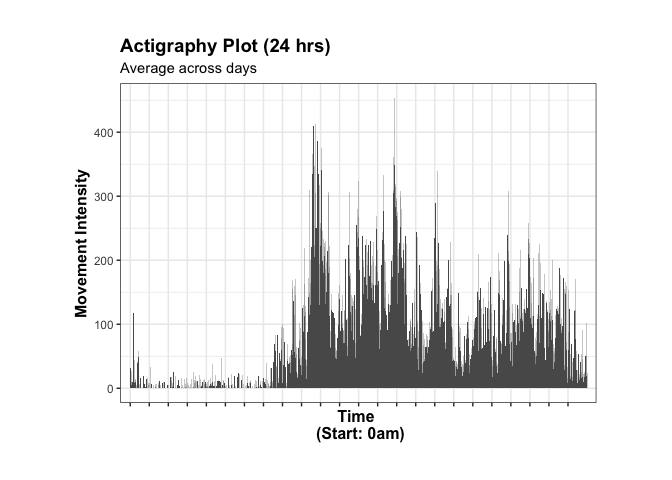

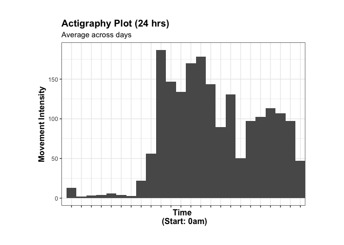

[figure not shown]

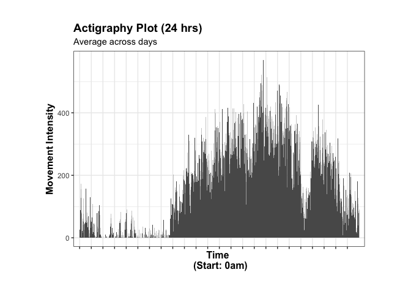

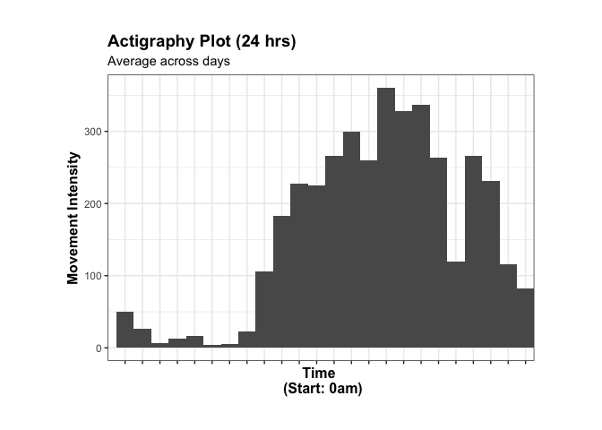

```r
results <- c()
for (file in list.files("~/Box/Aging Decision Making R01/RAs/Juo-Lin/data/preproc", pattern = "*.csv", full.names = TRUE)){
  act <- read.csv(file, header = FALSE)
  rar <- nparACT_base("act", SR = 2/60)
  rar$subject <-substring(basename(file), 0, 6)
  results <- rbind(results, rar)
}
write.csv(results, "~/Box/Aging Decision Making R01/RAs/Juo-Lin/data/cr_measures.csv")
```

## Prepare final data frame

Grouping by subject IDs, I merged the R56 REDCap Data and cr_measures and pivoted the gender variable. For the final data frame, I selected and filtered specific variables.

```r
rc <- read.csv("~/Box/Aging Decision Making R01/RAs/Juo-Lin/data/REDCap Data/R56 REDCap Data.csv")
cm <- read.csv("~/Box/Aging Decision Making R01/RAs/Juo-Lin/data/cr_measures.csv")

rc$subject_id <- stringr::str_pad(rc$record_id, width = 4, side = "left", pad = "0")
cm$subject_id <- substring(cm$subject, 3, 6)

df <- merge(rc, cm, by = c('subject_id'), all = T)

spec_df <- df %>%
  select(subject_id, starts_with("gender"), -gender_spec)

spec <- spec_df %>% build_longer_spec(
  cols = !subject_id,
  names_to = "gender",
  values_to = "count"
)

df1 <- pivot_longer_spec (spec_df, spec)
df1[df1 == 0] <- NA

df2 <- df1 %>%
  drop_na(count)

df3 <- merge(df2, df, by = c('subject_id'), all = T)

finaldf <- df3 %>%
  select(subject_id, redcap_event_name, age, IS, IV, RA, gender, contains("pre_bdi"), contains("pre_masq"), contains("pre_idas"), contains("pre_swls"), contains("pre_erq"), contains("pre_shap")) %>%
  group_by(subject_id) %>%
  fill(starts_with("gender"), .direction = "down") %>%
  ungroup() %>%
  filter(redcap_event_name == "session_1_arm_1") %>%
  drop_na(RA)

finaldf$gender <- gsub("gender___", "", as.character(finaldf$gender))
```

## Create Correlation Plots, Matrices, and Graphs

Code creates a violin plot with medians for gender and relative amplitute. It also renames the ticks so the graph reflects specific gender identities rather than a number that corresponds to the codebook.

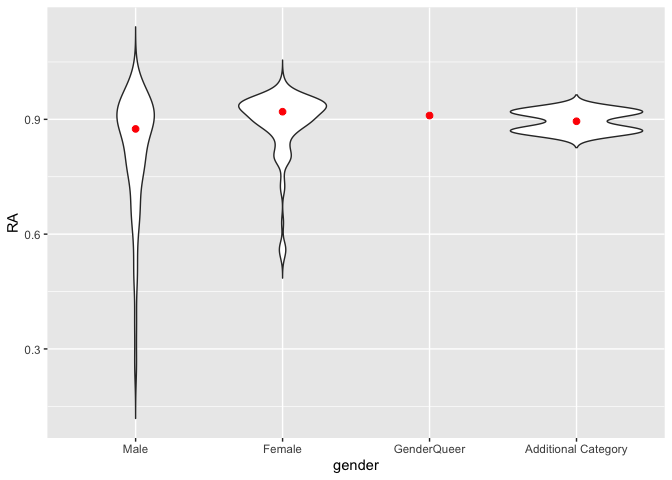

```r
finaldf$gender <- as.factor(finaldf$gender)

p <- ggplot(finaldf, aes(x = gender, y = RA)) +
  geom_violin(trim = FALSE)

ticks <- c("Male", "Female", "GenderQueer", "Additional Category")

p + scale_x_discrete(labels = ticks) + stat_summary(fun.y=median, geom="point", size=2, color="red")
```

By replacing “bdi” with the variable I want to measure, the code generates the matrix for the specific variable.

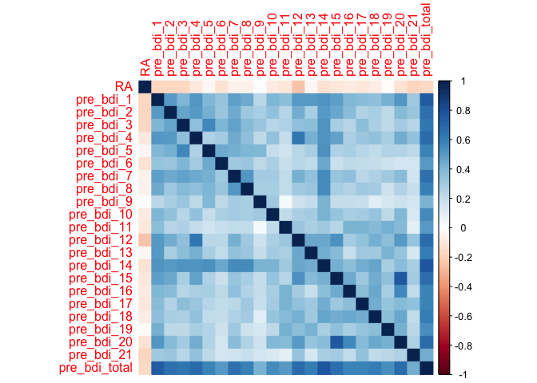

```r
ra_bdi <- finaldf %>%
  select (RA, contains("pre_bdi"))

correl_matrix <- data.matrix(ra_bdi)
correl_numeric_matrix <- as.matrix((sapply(ra_bdi, as.numeric)))
matrx <- cor(correl_numeric_matrix)
corrplot(matrx, method = "color")
```

This line of code calculates the correlation coefficient between the RA and the specific variable that was measured in the previous code. I disregard variables with a correlation coefficient <0.2.

```r
round(matrx, 2)
```

[output not shown]

By replacing “bdi” with the variable I want to measure, the code generates the scatterplot for the specific variable. It also identifies the linear relationship between the RA and the specific variable.

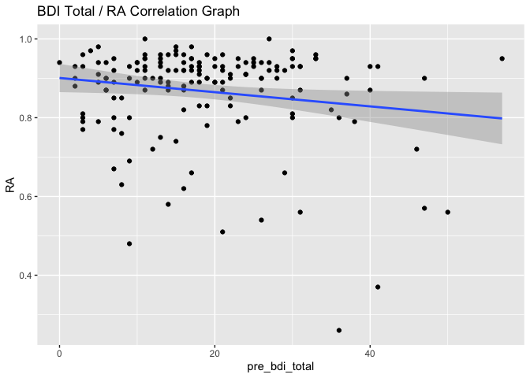

```r
ra_bdi_total <- ra_bdi %>%
  select(RA, "pre_bdi_total")
ggplot(ra_bdi_total, aes(x = pre_bdi_total, y = RA)) +
  geom_point() +
  stat_smooth(method = "lm") +
  ggtitle("BDI Total / RA Correlation Graph")
```

By replacing “erq” with the variable I want to measure, the code produces the Pearson correlation coefficient between the RA and the specific variable.

```r
cor.test(ra_erq$RA, ra_erq$pre_erq_total, method=c("pearson"))
```

[output not shown]